# intersect_RNA_ChIP_seq

Aldo Hernández Corchado

6/16/2020

### Relevant discussions:

https://stats.stackexchange.com/questions/72553/which-statistical-test-should-be-used-to-test-for-enrichment-of-gene-lists#72556 https://stats.stackexchange.com/questions/31633/is-the-overlap-between-two-gene-expression-samples-significant https://stats.stackexchange.com/questions/28232/fisher-test-in-r

## Data source

GEO dataset: `GSE51142`  
ChIP-seq pulldown: batch4_chrom1_LoVo_HOXA5_Rabbit_PassedQC (SRA: SRR1002428)  
ChIP-seq control: batch4_chrom1_LoVo_IgG_Rabbit_control (SRA: SRR1288206)

From:  
`Yan J, Enge M, Whitington T, Dave K et al. Transcription factor binding in human cells occurs in dense clusters formed around cohesin anchor sites. Cell 2013 Aug 15;154(4):801-13. PMID: 23953112`

## 1. Calling ChIP-seq peaks

ChIP-seq peaks were called as:

`macs --version # macs 1.4.2 20120305` `macs --treatment=${pull_down} --control=${control} -f BAM -g hs -n batch4_chrom1_LoVo_HOXA5_Rabbit --pvalue=0.001 --outdir=${OUT}/bed`

## 2. Get the closest genes.

Gencode reference: `tss_hg38=gencode.v33.basic.annotation_transcript.gff3`

Command to get the closest genes to the ChIP-seq peaks for HOXA5: `time bedtools closest -d -a ${summits} -b ${tss_hg38} > closest_transcripts_to_HOXA5_summit.bed`

## 3. Filtering of ChIP-seq peaks

```
## Filtering peaks:
##  1. distance to gene < 500
##  2. FDR(%) <= 0.2
```

bed file with closest genes to HOXA5 ChIP-seq summit

|  | chr | start | end | length | summit | tags | -10*log10(pvalue) | fold_enrichment | FDR(%) | V10 | V11 | V12 | V13 | V14 | V15 | V16 | V17 | V18 | distance_to_gene |
| --- | --- | --- | --- | --- | --- | --- | --- | --- | --- | --- | --- | --- | --- | --- | --- | --- | --- | --- | --- |
| 1 | chr1 | 629937 | 629938 | 989 | 351 | 47 | 57.59 | 5.65 | 0.00 | chr1 | HAVANA | transcript | 594308 | 827796 | . | - | . | ID=ENST00000634337.2;Parent=ENSG00000230021.10;gene_id=ENSG00000230021.10;transcript_id=ENST00000634337.2;gene_type=transcribed_processed_pseudogene;gene_name=AL669831.3;transcript_type=processed_tran… | 0 |
| 2 | chr1 | 629937 | 629938 | 989 | 351 | 47 | 57.59 | 5.65 | 0.00 | chr1 | HAVANA | transcript | 629640 | 630683 | . | + | . | ID=ENST00000457540.1;Parent=ENSG00000225630.1;gene_id=ENSG00000225630.1;transcript_id=ENST00000457540.1;gene_type=unprocessed_pseudogene;gene_name=MTND2P28;transcript_type=unprocessed_pseudogene;trans… | 0 |
| 3 | chr1 | 634027 | 634028 | 914 | 495 | 60 | 99.58 | 6.53 | 0.00 | chr1 | HAVANA | transcript | 594308 | 827796 | . | - | . | ID=ENST00000634337.2;Parent=ENSG00000230021.10;gene_id=ENSG00000230021.10;transcript_id=ENST00000634337.2;gene_type=transcribed_processed_pseudogene;gene_name=AL669831.3;transcript_type=processed_tran… | 0 |
| 4 | chr1 | 634027 | 634028 | 914 | 495 | 60 | 99.58 | 6.53 | 0.00 | chr1 | HAVANA | transcript | 633696 | 634376 | . | + | . | ID=ENST00000514057.1;Parent=ENSG00000248527.1;gene_id=ENSG00000248527.1;transcript_id=ENST00000514057.1;gene_type=unprocessed_pseudogene;gene_name=MTATP6P1;transcript_type=unprocessed_pseudogene;trans… | 0 |
| 10 | chr1 | 904552 | 904553 | 1114 | 247 | 11 | 46.63 | 8.38 | 0.08 | chr1 | HAVANA | transcript | 904834 | 915976 | . | + | . | ID=ENST00000607769.1;Parent=ENSG00000272438.1;gene_id=ENSG00000272438.1;transcript_id=ENST00000607769.1;gene_type=lncRNA;gene_name=AL645608.6;transcript_type=lncRNA;transcript_name=AL645608.6-201;leve… | 281 |

```
##
## Genes close to HOXA peaks: 4765
```

```
## Example of genes ...
```

```
## AL669831.3 MTND2P28 MTATP6P1 AL645608.6 PLEKHN1 HES4
```

## 4. Load differentially expressed genes from RNA-seq

```
## HOXA ChIP-seq genes: 4765
##
## All genes measured by RNA-seq: 18207
##
## RNA-seq genes filters:
##
## Adjusted p-value: 0.1
##              LFC: -0.5 and + 0.5
##
##  Dysregulated RNA-seq genes: 2780
##   Upregulated RNA-seq genes: 1284
## Downregulated RNA-seq genes: 1496
```

## 5. Test if the overlap is significant

We perfom a Fisher’s exact test for testing similar to:  
https://stats.stackexchange.com/questions/31633/is-the-overlap-between-two-gene-expression-samples-significant

contigency table examples

|  | ChIP_yes | ChIP_no |
| --- | --- | --- |
| RNA_yes | RNA/ChIP-seq intersect | RNA-seq only |
| RNA_no | ChIP-seq only | Other |

### 5.1 Testing the overlap for HOXA5 and **all** DEG from RNA-seq

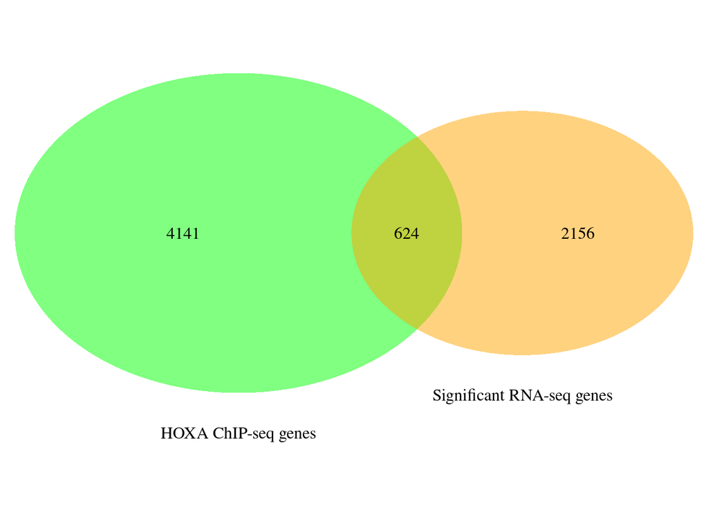

Total # of genes measured by RNA-seq: 18207

contigency table 2

|  | ChIP_yes | ChIP_no |
| --- | --- | --- |
| RNA_yes | 624 | 2156 |
| RNA_no | 4141 | 11286 |

```
## p-value: 0.999999613370704
```

### 5.2 Testing the overlap for HOXA5 and **upregulated** DEG from RNA-seq

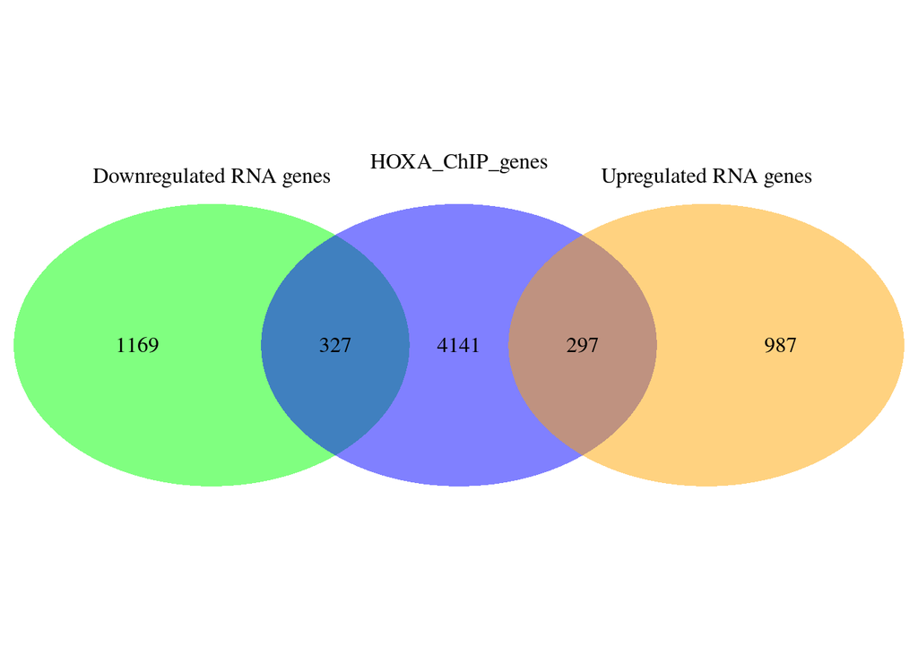

Total # of genes measured by RNA-seq and ChIP-seq: 18207

contigency table upregulated RNA

|  | ChIP_yes | ChIP_no |
| --- | --- | --- |
| RNA_yes | 297 | 987 |
| RNA_no | 4468 | 12455 |

```
## p-value: 0.995750642613631
```

### 5.3 Testing the overlap for HOXA5 and **downregulated** DEG from RNA-seq

[output not shown]

```
## p-value: 0.892053557986956
```

## 6. Enriched pathways in the overlapped genes

## 6.1 Enriched pathways in the intersection of HOXA ChIP-seq and DEG RNA-seq (**all** genes)

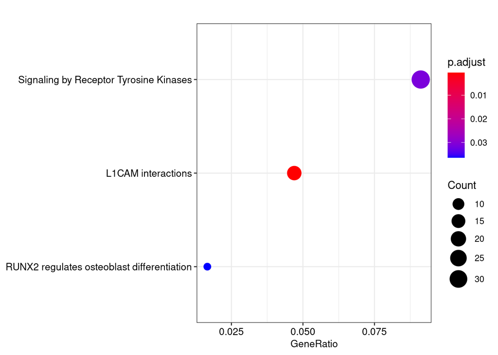

## 6.2 Enriched pathways in the intersection of HOXA ChIP-seq and DEG RNA-seq (**Upregulated** genes)

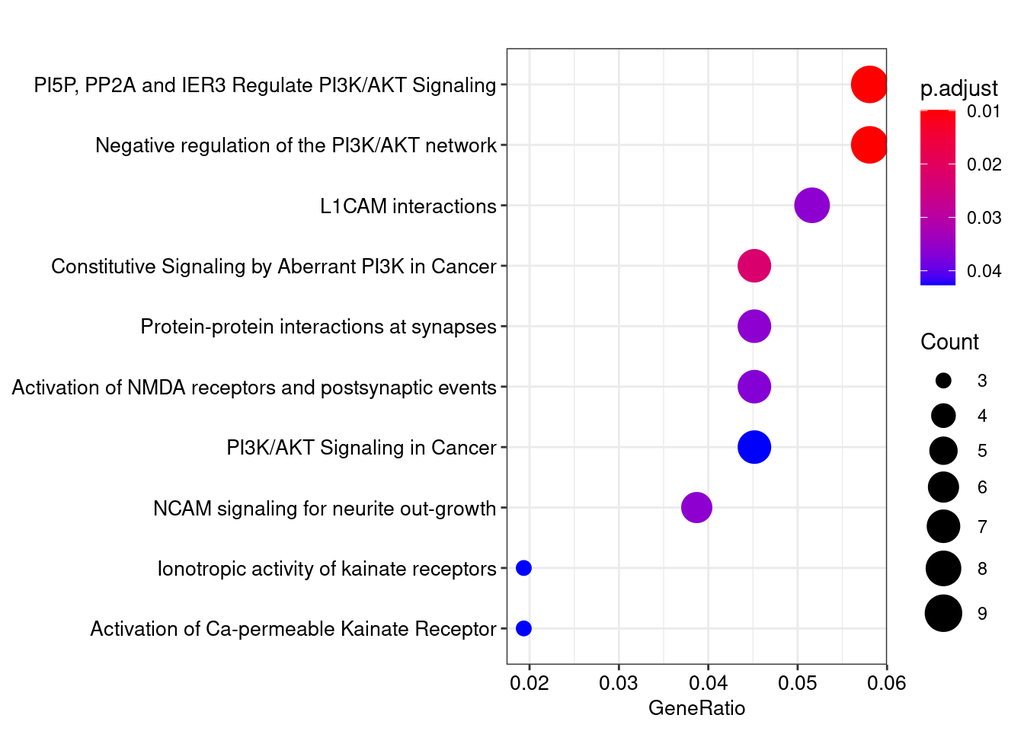

[figure not shown]